# Project: Wrangling and Analyze Data

1. IMPORTING PACKAGES
2. DATA GATHERING
3. ASSESSING DATA
   1. VISUAL ASSESSMENT
   2. PROGRAMMATIC ASSESSMENT
   3. QUALITY ISSUES
   4. TIDINESS ISSUES
4. DATA CLEANING
5. STORING DATA
6. ANALYZING AND VISUALIZING DATA

### IMPORTING PACKAGES

```python
import matplotlib.pyplot as plt
import seaborn as sns
import pandas as pd
import numpy as np
import requests
import json
import os
```

## Data Gathering

In cells below, we would gather **all** three pieces of data for this project and load them in the notebook.

#### 1) Extracting enhanced twitter archive provided

```python
twitter_archive_df = pd.read_csv("twitter-archive-enhanced.csv")
```

#### 2) Using Requests library to download the tweet image prediction (image_predictions.tsv)

```python
url = 'https://d17h27t6h515a5.cloudfront.net/topher/2017/August/599fd2ad_image-predictions/image-predictions.tsv'
res = requests.get(url)
filename = url.split('/')[-1]
if not os.path.exists(filename):
    with open(filename,"wb") as file:
        file.write(res.content)

# reading file image_predictions.tsv

img_pred_df = pd.read_csv("image-predictions.tsv", sep='\t')
```

#### 3) Extracting tweets from (tweet_json.txt)

```python
tweets = []
tweet_file= 'tweet_json.txt'
with open(tweet_file,encoding='utf-8') as file:
    for lines in file:
        tweet_data = json.loads(lines)
        tweet_id = tweet_data['id']
        retweet_count = tweet_data['retweet_count']
        favorite_count = tweet_data['favorite_count']
        source = tweet_data['source']
        tweets.append({'tweet_id':tweet_id,'retweets_count':retweet_count,'favorite_count':favorite_count,'source':source})

tweets_df = pd.DataFrame(tweets)
```

## Assessing Data

In this section, we would be detecting and documenting at least **eight (8) quality issues and two (2) tidiness issue**, using both visual assessment and programmatic assessement to assess the our datasets.

#### VISUAL ASSESSMENT

**Twitter_archive sampling assesment.**

```python
twitter_archive_df.sample(5)
```

|  | tweet_id | in_reply_to_status_id | in_reply_to_user_id | timestamp | source | text | retweeted_status_id | retweeted_status_user_id | retweeted_status_timestamp | expanded_urls | rating_numerator | rating_denominator | name | doggo | floofer | pupper | puppo |
| --- | --- | --- | --- | --- | --- | --- | --- | --- | --- | --- | --- | --- | --- | --- | --- | --- | --- |
| 859 | 763183847194451968 | NaN | NaN | 2016-08-10 01:23:03 +0000 | <a href="http://twitter.com/download/iphone" r... | This is Clark. He collects teddy bears. It's a... | NaN | NaN | NaN | https://twitter.com/dog_rates/status/763183847... | 8 | 10 | Clark | None | None | None | None |
| 1767 | 678396796259975168 | NaN | NaN | 2015-12-20 02:09:34 +0000 | <a href="http://twitter.com/download/iphone" r... | These little fellas have opposite facial expre... | NaN | NaN | NaN | https://twitter.com/dog_rates/status/678396796... | 12 | 10 | None | None | None | None | None |
| 407 | 823699002998870016 | NaN | NaN | 2017-01-24 01:08:40 +0000 | <a href="http://twitter.com/download/iphone" r... | This is Winston. The goggles make him a superh... | NaN | NaN | NaN | https://twitter.com/dog_rates/status/823699002... | 12 | 10 | Winston | None | None | None | None |
| 2354 | 666029285002620928 | NaN | NaN | 2015-11-15 23:05:30 +0000 | <a href="http://twitter.com/download/iphone" r... | This is a western brown Mitsubishi terrier. Up... | NaN | NaN | NaN | https://twitter.com/dog_rates/status/666029285... | 7 | 10 | a | None | None | None | None |
| 754 | 778764940568104960 | NaN | NaN | 2016-09-22 01:16:45 +0000 | <a href="http://twitter.com/download/iphone" r... | Oh my god it's Narcos but Barkos. 13/10 someon... | NaN | NaN | NaN | https://m.youtube.com/watch?v=idKxCMsS3FQ&feat... | 13 | 10 | None | None | None | None | None |

**Image Predictions Assessment**

```python
img_pred_df.sample(5)
```

|  | tweet_id | jpg_url | img_num | p1 | p1_conf | p1_dog | p2 | p2_conf | p2_dog | p3 | p3_conf | p3_dog |
| --- | --- | --- | --- | --- | --- | --- | --- | --- | --- | --- | --- | --- |
| 930 | 703041949650034688 | https://pbs.twimg.com/media/CcG07BYW0AErrC9.jpg | 1 | hippopotamus | 0.581403 | False | doormat | 0.152445 | False | sea_lion | 0.026364 | False |
| 1079 | 717841801130979328 | https://pbs.twimg.com/media/CfZJTphWAAAl5Ys.jpg | 1 | Brittany_spaniel | 0.922876 | True | English_springer | 0.070113 | True | bath_towel | 0.002561 | False |
| 942 | 704113298707505153 | https://pbs.twimg.com/media/CcWDTerUAAALORn.jpg | 2 | otter | 0.945537 | False | mink | 0.018231 | False | sea_lion | 0.015861 | False |
| 313 | 671561002136281088 | https://pbs.twimg.com/media/CVHdK-7WwAAsuyc.jpg | 1 | Gordon_setter | 0.469373 | True | black-and-tan_coonhound | 0.270893 | True | Rottweiler | 0.153233 | True |
| 723 | 686007916130873345 | https://pbs.twimg.com/media/CYUwjz-UAAEcdi8.jpg | 1 | Rhodesian_ridgeback | 0.885301 | True | redbone | 0.042335 | True | seat_belt | 0.010493 | False |

**Tweets dataframe assessment.**

```python
tweets_df.sample(5)
```

|  | tweet_id | retweets_count | favorite_count | source |
| --- | --- | --- | --- | --- |
| 1376 | 701570477911896070 | 1055 | 3080 | <a href="http://twitter.com/download/iphone" r... |
| 2187 | 668967877119254528 | 25 | 161 | <a href="http://twitter.com/download/iphone" r... |
| 1222 | 714214115368108032 | 990 | 2480 | <a href="http://twitter.com/download/iphone" r... |
| 1580 | 687109925361856513 | 2803 | 6370 | <a href="http://twitter.com/download/iphone" r... |
| 2103 | 670474236058800128 | 835 | 1635 | <a href="http://twitter.com/download/iphone" r... |

### Twitter_archive

```python
twitter_archive_df.info()
```

```
<class 'pandas.core.frame.DataFrame'>
RangeIndex: 2356 entries, 0 to 2355
Data columns (total 17 columns):
 #   Column                      Non-Null Count  Dtype
---  ------                      --------------  -----
 0   tweet_id                    2356 non-null   int64
 1   in_reply_to_status_id       78 non-null     float64
 2   in_reply_to_user_id         78 non-null     float64
 3   timestamp                   2356 non-null   object
 4   source                      2356 non-null   object
 5   text                        2356 non-null   object
 6   retweeted_status_id         181 non-null    float64
 7   retweeted_status_user_id    181 non-null    float64
 8   retweeted_status_timestamp  181 non-null    object
 9   expanded_urls               2297 non-null   object
 10  rating_numerator            2356 non-null   int64
 11  rating_denominator          2356 non-null   int64
 12  name                        2356 non-null   object
 13  doggo                       2356 non-null   object
 14  floofer                     2356 non-null   object
 15  pupper                      2356 non-null   object
 16  puppo                       2356 non-null   object
dtypes: float64(4), int64(3), object(10)
memory usage: 313.0+ KB
```

```python
twitter_archive_df.shape
```

```
(2356, 17)
```

```python
twitter_archive_df.describe()
```

|  | tweet_id | in_reply_to_status_id | in_reply_to_user_id | retweeted_status_id | retweeted_status_user_id | rating_numerator | rating_denominator |
| --- | --- | --- | --- | --- | --- | --- | --- |
| count | 2.356000e+03 | 7.800000e+01 | 7.800000e+01 | 1.810000e+02 | 1.810000e+02 | 2356.000000 | 2356.000000 |
| mean | 7.427716e+17 | 7.455079e+17 | 2.014171e+16 | 7.720400e+17 | 1.241698e+16 | 13.126486 | 10.455433 |
| std | 6.856705e+16 | 7.582492e+16 | 1.252797e+17 | 6.236928e+16 | 9.599254e+16 | 45.876648 | 6.745237 |
| min | 6.660209e+17 | 6.658147e+17 | 1.185634e+07 | 6.661041e+17 | 7.832140e+05 | 0.000000 | 0.000000 |
| 25% | 6.783989e+17 | 6.757419e+17 | 3.086374e+08 | 7.186315e+17 | 4.196984e+09 | 10.000000 | 10.000000 |
| 50% | 7.196279e+17 | 7.038708e+17 | 4.196984e+09 | 7.804657e+17 | 4.196984e+09 | 11.000000 | 10.000000 |
| 75% | 7.993373e+17 | 8.257804e+17 | 4.196984e+09 | 8.203146e+17 | 4.196984e+09 | 12.000000 | 10.000000 |
| max | 8.924206e+17 | 8.862664e+17 | 8.405479e+17 | 8.874740e+17 | 7.874618e+17 | 1776.000000 | 170.000000 |

```python
twitter_archive_df.duplicated().sum()
```

```
0
```

```python
twitter_archive_df.nunique()
```

```
tweet_id                      2356
in_reply_to_status_id           77
in_reply_to_user_id             31
timestamp                     2356
source                           4
text                          2356
retweeted_status_id            181
retweeted_status_user_id        25
retweeted_status_timestamp     181
expanded_urls                 2218
rating_numerator                40
rating_denominator              18
name                           957
doggo                            2
floofer                          2
pupper                           2
puppo                            2
dtype: int64
```

```python
# checking for missing values in archive
twitter_archive_df.isna().sum()
```

```
tweet_id                         0
in_reply_to_status_id         2278
in_reply_to_user_id           2278
timestamp                        0
source                           0
text                             0
retweeted_status_id           2175
retweeted_status_user_id      2175
retweeted_status_timestamp    2175
expanded_urls                   59
rating_numerator                 0
rating_denominator               0
name                             0
doggo                            0
floofer                          0
pupper                           0
puppo                            0
dtype: int64
```

### Image_predictions

```python
img_pred_df.info()
```

```
<class 'pandas.core.frame.DataFrame'>
RangeIndex: 2075 entries, 0 to 2074
Data columns (total 12 columns):
 #   Column    Non-Null Count  Dtype
---  ------    --------------  -----
 0   tweet_id  2075 non-null   int64
 1   jpg_url   2075 non-null   object
 2   img_num   2075 non-null   int64
 3   p1        2075 non-null   object
 4   p1_conf   2075 non-null   float64
 5   p1_dog    2075 non-null   bool
 6   p2        2075 non-null   object
 7   p2_conf   2075 non-null   float64
 8   p2_dog    2075 non-null   bool
 9   p3        2075 non-null   object
 10  p3_conf   2075 non-null   float64
 11  p3_dog    2075 non-null   bool
dtypes: bool(3), float64(3), int64(2), object(4)
memory usage: 152.1+ KB
```

```python
img_pred_df.shape
```

```
(2075, 12)
```

```python
img_pred_df.describe()
```

|  | tweet_id | img_num | p1_conf | p2_conf | p3_conf |
| --- | --- | --- | --- | --- | --- |
| count | 2.075000e+03 | 2075.000000 | 2075.000000 | 2.075000e+03 | 2.075000e+03 |
| mean | 7.384514e+17 | 1.203855 | 0.594548 | 1.345886e-01 | 6.032417e-02 |
| std | 6.785203e+16 | 0.561875 | 0.271174 | 1.006657e-01 | 5.090593e-02 |
| min | 6.660209e+17 | 1.000000 | 0.044333 | 1.011300e-08 | 1.740170e-10 |
| 25% | 6.764835e+17 | 1.000000 | 0.364412 | 5.388625e-02 | 1.622240e-02 |
| 50% | 7.119988e+17 | 1.000000 | 0.588230 | 1.181810e-01 | 4.944380e-02 |
| 75% | 7.932034e+17 | 1.000000 | 0.843855 | 1.955655e-01 | 9.180755e-02 |
| max | 8.924206e+17 | 4.000000 | 1.000000 | 4.880140e-01 | 2.734190e-01 |

```python
img_pred_df.duplicated().sum()
```

```
0
```

```python
img_pred_df.nunique()
```

```
tweet_id    2075
jpg_url     2009
img_num        4
p1           378
p1_conf     2006
p1_dog         2
p2           405
p2_conf     2004
p2_dog         2
p3           408
p3_conf     2006
p3_dog         2
dtype: int64
```

```python
# Checking for missing values in image_predicted
img_pred_df.isnull().sum()
```

```
tweet_id    0
jpg_url     0
img_num     0
p1          0
p1_conf     0
p1_dog      0
p2          0
p2_conf     0
p2_dog      0
p3          0
p3_conf     0
p3_dog      0
dtype: int64
```

### Tweets dataframe

```python
tweets_df.info()
```

```
<class 'pandas.core.frame.DataFrame'>
RangeIndex: 2354 entries, 0 to 2353
Data columns (total 4 columns):
 #   Column          Non-Null Count  Dtype
---  ------          --------------  -----
 0   tweet_id        2354 non-null   int64
 1   retweets_count  2354 non-null   int64
 2   favorite_count  2354 non-null   int64
 3   source          2354 non-null   object
dtypes: int64(3), object(1)
memory usage: 73.7+ KB
```

```python
tweets_df.shape
```

```
(2354, 4)
```

```python
tweets_df.describe()
```

|  | tweet_id | retweets_count | favorite_count |
| --- | --- | --- | --- |
| count | 2.354000e+03 | 2354.000000 | 2354.000000 |
| mean | 7.426978e+17 | 3164.797366 | 8080.968564 |
| std | 6.852812e+16 | 5284.770364 | 11814.771334 |
| min | 6.660209e+17 | 0.000000 | 0.000000 |
| 25% | 6.783975e+17 | 624.500000 | 1415.000000 |
| 50% | 7.194596e+17 | 1473.500000 | 3603.500000 |
| 75% | 7.993058e+17 | 3652.000000 | 10122.250000 |
| max | 8.924206e+17 | 79515.000000 | 132810.000000 |

```python
tweets_df.duplicated().sum()
```

```
0
```

```python
tweets_df.nunique()
```

```
tweet_id          2354
retweets_count    1724
favorite_count    2007
source               4
dtype: int64
```

```python
#checking for missing values in tweets
tweets_df.isna().sum()
```

```
tweet_id          0
retweets_count    0
favorite_count    0
source            0
dtype: int64
```

### Quality issues

#### twitter_archive

> ```
> 1. (+0000) to be removed at timestamp values.
> 2. Timestamp should be Datetime dtype.
> 3. The source should be extracted from the hyperlink at source columns.
> 4. keeping only original tweets and no retweets.
> 5. Columns with NaN entries to be dropped.
> 6. Names as lower case and not valid names ('a','such','the','just','getting').
> 7. Presence of 0 and outliers values rating_numerator column.
> ```

#### Image_predictions dataframe.

> ```
> 8. Dropping rows in df_image_predictions with p1_dog == false.
> ```

### Tidiness issues

> 1. concatenate dog stages columns i.e. (doggo, floofer, pupper and puppo), there are cases with multiple dog stages in a row.
> 2. df_tweets and df_image_predictions (jpg_url, p1, p1_conf) can be merged to df_twitter_archive as one datasets

## Cleaning Data

In this section, we would be cleaning **all** of the issues you documented above.

```python
# Make copies of original pieces of data
twitter_archive_clean = twitter_archive_df.copy()
img_pred_clean = img_pred_df.copy()
tweets_df_clean = tweets_df.copy()
```

### Quality Issue #1:

- (+0000) to be removed at df_twitter_archive timestamp values

#### Define: Remove (+0000) df_twitter_archive timestamp using string slicing.

#### Code

```python
 twitter_archive_clean['timestamp'] = twitter_archive_clean.timestamp.str[0:-5]
```

#### Test

```python
twitter_archive_clean['timestamp']
```

```
0       2017-08-01 16:23:56
1       2017-08-01 00:17:27
2       2017-07-31 00:18:03
3       2017-07-30 15:58:51
4       2017-07-29 16:00:24
                ...
2351    2015-11-16 00:24:50
2352    2015-11-16 00:04:52
2353    2015-11-15 23:21:54
2354    2015-11-15 23:05:30
2355    2015-11-15 22:32:08
Name: timestamp, Length: 2356, dtype: object
```

### Quality Issue #2:

- timestamp in twitter_archive should be Datetime dtype

#### Define: change timestamp in df_twitter_archive using pd.to_datetime.

#### Code

```python
twitter_archive_clean['timestamp'] = pd.to_datetime(twitter_archive_clean['timestamp'])
```

#### Test

```python
twitter_archive_clean.info()
```

```
<class 'pandas.core.frame.DataFrame'>
RangeIndex: 2356 entries, 0 to 2355
Data columns (total 17 columns):
 #   Column                      Non-Null Count  Dtype
---  ------                      --------------  -----
 0   tweet_id                    2356 non-null   int64
 1   in_reply_to_status_id       78 non-null     float64
 2   in_reply_to_user_id         78 non-null     float64
 3   timestamp                   2356 non-null   datetime64[ns]
 4   source                      2356 non-null   object
 5   text                        2356 non-null   object
 6   retweeted_status_id         181 non-null    float64
 7   retweeted_status_user_id    181 non-null    float64
 8   retweeted_status_timestamp  181 non-null    object
 9   expanded_urls               2297 non-null   object
 10  rating_numerator            2356 non-null   int64
 11  rating_denominator          2356 non-null   int64
 12  name                        2356 non-null   object
 13  doggo                       2356 non-null   object
 14  floofer                     2356 non-null   object
 15  pupper                      2356 non-null   object
 16  puppo                       2356 non-null   object
dtypes: datetime64[ns](1), float64(4), int64(3), object(9)
memory usage: 313.0+ KB
```

### Quality Issue #3:

- The source should be extracted from the hyperlink values given in the source columns.

#### Define: Use regex and str.extract to obtain source from hyperlink

#### Code

```python
twitter_archive_clean['source'] = twitter_archive_clean['source'].str.extract('(?:.*>)([a-zA-Z-\s]+)(?:.*<)')
```

### Test

```python
twitter_archive_clean.source.head()
```

```
0    Twitter for iPhone
1    Twitter for iPhone
2    Twitter for iPhone
3    Twitter for iPhone
4    Twitter for iPhone
Name: source, dtype: object
```

### Quality Issue #4:

- keeping only original tweets in Twitter_archive datasets.

#### Define: Drop rows containing retweet_status and in_reply_to.

#### Code

```python
# dropping non-empty cells for retweets and replies
twitter_archive_clean.query("retweeted_status_id != retweeted_status_id & in_reply_to_status_id != in_reply_to_status_id",
                            inplace=True)
```

#### Test

```python
twitter_archive_clean.retweeted_status_id.notna().sum()
```

```
0
```

```python
twitter_archive_clean.in_reply_to_status_id.notna().sum()
```

```
0
```

### Quality Issue #5:

- columns with NaN entries to be dropped in twitter_archive.

#### Define: drop column using df.drop()

#### Code

```python
twitter_archive_clean.drop(columns= ['retweeted_status_user_id',
                                     'in_reply_to_user_id','in_reply_to_status_id','retweeted_status_user_id',
                                    'retweeted_status_id','retweeted_status_timestamp'], inplace=True)
```

#### Test

```python
twitter_archive_clean.columns
```

```
Index(['tweet_id', 'timestamp', 'source', 'text', 'expanded_urls',
       'rating_numerator', 'rating_denominator', 'name', 'doggo', 'floofer',
       'pupper', 'puppo'],
      dtype='object')
```

### Quality Issue #6:

- Dropping rows image_predictions having p1_dog as false.

#### Define: Use df.query to obtain image predictions p1_dog != false.

#### Code

```python
img_pred_clean.query("p1_dog != False", inplace=True)
```

#### Test

```python
img_pred_clean.query("p1_dog == False")
```

|  | tweet_id | jpg_url | img_num | p1 | p1_conf | p1_dog | p2 | p2_conf | p2_dog | p3 | p3_conf | p3_dog |
| --- | --- | --- | --- | --- | --- | --- | --- | --- | --- | --- | --- | --- |

### Quality Issue #7:

- Names as lower case and invalid names in twitter_archive name column

#### Define: Replace all invalid and lower case name with NaN.

#### Code

```python
mask = twitter_archive_clean.name.str.islower()

twitter_archive_clean.loc[mask,'name'] = np.nan
```

#### Test

```python
twitter_archive_clean.loc[mask,'name']
```

```
22      NaN
56      NaN
169     NaN
193     NaN
335     NaN
       ...
2349    NaN
2350    NaN
2352    NaN
2353    NaN
2354    NaN
Name: name, Length: 104, dtype: object
```

### Quality Issue #8:

- Presence of 0 in twitter_archive rating_numerator column value.

#### Define: filter rating_numerator == 0 and drop

#### Code

```python
twitter_archive_clean.query('rating_numerator == 0')
```

|  | tweet_id | timestamp | source | text | expanded_urls | rating_numerator | rating_denominator | name | doggo | floofer | pupper | puppo |
| --- | --- | --- | --- | --- | --- | --- | --- | --- | --- | --- | --- | --- |
| 315 | 835152434251116546 | 2017-02-24 15:40:31 | Twitter for iPhone | When you're so blinded by your systematic plag... | https://twitter.com/dog_rates/status/835152434... | 0 | 10 | None | None | None | None | None |

```python
twitter_archive_clean.drop(index=315,inplace=True)
```

#### Test

```python
twitter_archive_clean.query('rating_numerator == 0')
```

|  | tweet_id | timestamp | source | text | expanded_urls | rating_numerator | rating_denominator | name | doggo | floofer | pupper | puppo |
| --- | --- | --- | --- | --- | --- | --- | --- | --- | --- | --- | --- | --- |

### Tidiness Issue #1:

#### Define: Concatenate dog stages columns i.e. (doggo, floofer, pupper and puppo), there are cases with multiple dog stages in a row.

#### Code

```python
# Extracting desired column

DogStage = twitter_archive_clean[['tweet_id','name', 'doggo', 'floofer', 'pupper', 'puppo']]

df_dogstage = (DogStage.set_index(['tweet_id','name'])
         .replace('None', np.nan)
         .apply(lambda x: ','.join(x.dropna()), axis=1)
         .reset_index(name='dog_stage'))

# Merging to original dataframe

twitter_archive_clean = twitter_archive_clean.merge(df_dogstage, on=['tweet_id','name'], how='inner')

# dropping columns

twitter_archive_clean.drop(columns=['doggo','floofer','pupper','puppo'],inplace=True)
```

#### Test

```python
twitter_archive_clean.columns
```

```
Index(['tweet_id', 'timestamp', 'source', 'text', 'expanded_urls',
       'rating_numerator', 'rating_denominator', 'name', 'dog_stage'],
      dtype='object')
```

```python
twitter_archive_clean.head()
```

|  | tweet_id | timestamp | source | text | expanded_urls | rating_numerator | rating_denominator | name | dog_stage |
| --- | --- | --- | --- | --- | --- | --- | --- | --- | --- |
| 0 | 892420643555336193 | 2017-08-01 16:23:56 | Twitter for iPhone | This is Phineas. He's a mystical boy. Only eve... | https://twitter.com/dog_rates/status/892420643... | 13 | 10 | Phineas |  |
| 1 | 892177421306343426 | 2017-08-01 00:17:27 | Twitter for iPhone | This is Tilly. She's just checking pup on you.... | https://twitter.com/dog_rates/status/892177421... | 13 | 10 | Tilly |  |
| 2 | 891815181378084864 | 2017-07-31 00:18:03 | Twitter for iPhone | This is Archie. He is a rare Norwegian Pouncin... | https://twitter.com/dog_rates/status/891815181... | 12 | 10 | Archie |  |
| 3 | 891689557279858688 | 2017-07-30 15:58:51 | Twitter for iPhone | This is Darla. She commenced a snooze mid meal... | https://twitter.com/dog_rates/status/891689557... | 13 | 10 | Darla |  |
| 4 | 891327558926688256 | 2017-07-29 16:00:24 | Twitter for iPhone | This is Franklin. He would like you to stop ca... | https://twitter.com/dog_rates/status/891327558... | 12 | 10 | Franklin |  |

### Tidiness Issue #2: (Merging)

- Tweets and Image_predictions can be merged to Twitter_archive as one datasets

#### Define: Merge twitter_archive_df with tweet_df on tweet_id

#### Code

```python
# Merging df_twitter_archive and df_tweet
twitter_archive_clean = pd.merge(twitter_archive_clean, tweets_df_clean[['tweet_id','retweets_count','favorite_count']],
                            on=['tweet_id'], how='inner')
```

#### Test

```python
twitter_archive_clean.head()
```

|  | tweet_id | timestamp | source | text | expanded_urls | rating_numerator | rating_denominator | name | dog_stage | retweets_count | favorite_count |
| --- | --- | --- | --- | --- | --- | --- | --- | --- | --- | --- | --- |
| 0 | 892420643555336193 | 2017-08-01 16:23:56 | Twitter for iPhone | This is Phineas. He's a mystical boy. Only eve... | https://twitter.com/dog_rates/status/892420643... | 13 | 10 | Phineas |  | 8853 | 39467 |
| 1 | 892177421306343426 | 2017-08-01 00:17:27 | Twitter for iPhone | This is Tilly. She's just checking pup on you.... | https://twitter.com/dog_rates/status/892177421... | 13 | 10 | Tilly |  | 6514 | 33819 |
| 2 | 891815181378084864 | 2017-07-31 00:18:03 | Twitter for iPhone | This is Archie. He is a rare Norwegian Pouncin... | https://twitter.com/dog_rates/status/891815181... | 12 | 10 | Archie |  | 4328 | 25461 |
| 3 | 891689557279858688 | 2017-07-30 15:58:51 | Twitter for iPhone | This is Darla. She commenced a snooze mid meal... | https://twitter.com/dog_rates/status/891689557... | 13 | 10 | Darla |  | 8964 | 42908 |
| 4 | 891327558926688256 | 2017-07-29 16:00:24 | Twitter for iPhone | This is Franklin. He would like you to stop ca... | https://twitter.com/dog_rates/status/891327558... | 12 | 10 | Franklin |  | 9774 | 41048 |

#### Define: Merge twitter_archive_df with Image_predictions_df on tweet_id and only include image_predictions_df (jpg_url, p1, p1_conf)

#### Code

```python
twitter_archive_clean = twitter_archive_clean.merge(img_pred_clean[['tweet_id','jpg_url','p1','p1_conf']],
                                                    on='tweet_id', how='inner')
```

#### Test

```python
twitter_archive_clean.head()
```

|  | tweet_id | timestamp | source | text | expanded_urls | rating_numerator | rating_denominator | name | dog_stage | retweets_count | favorite_count | jpg_url | p1 | p1_conf |
| --- | --- | --- | --- | --- | --- | --- | --- | --- | --- | --- | --- | --- | --- | --- |
| 0 | 892177421306343426 | 2017-08-01 00:17:27 | Twitter for iPhone | This is Tilly. She's just checking pup on you.... | https://twitter.com/dog_rates/status/892177421... | 13 | 10 | Tilly |  | 6514 | 33819 | https://pbs.twimg.com/media/DGGmoV4XsAAUL6n.jpg | Chihuahua | 0.323581 |
| 1 | 891815181378084864 | 2017-07-31 00:18:03 | Twitter for iPhone | This is Archie. He is a rare Norwegian Pouncin... | https://twitter.com/dog_rates/status/891815181... | 12 | 10 | Archie |  | 4328 | 25461 | https://pbs.twimg.com/media/DGBdLU1WsAANxJ9.jpg | Chihuahua | 0.716012 |
| 2 | 891327558926688256 | 2017-07-29 16:00:24 | Twitter for iPhone | This is Franklin. He would like you to stop ca... | https://twitter.com/dog_rates/status/891327558... | 12 | 10 | Franklin |  | 9774 | 41048 | https://pbs.twimg.com/media/DF6hr6BUMAAzZgT.jpg | basset | 0.555712 |
| 3 | 891087950875897856 | 2017-07-29 00:08:17 | Twitter for iPhone | Here we have a majestic great white breaching ... | https://twitter.com/dog_rates/status/891087950... | 13 | 10 | None |  | 3261 | 20562 | https://pbs.twimg.com/media/DF3HwyEWsAABqE6.jpg | Chesapeake_Bay_retriever | 0.425595 |
| 4 | 890971913173991426 | 2017-07-28 16:27:12 | Twitter for iPhone | Meet Jax. He enjoys ice cream so much he gets ... | https://gofundme.com/ydvmve-surgery-for-jax,ht... | 13 | 10 | Jax |  | 2158 | 12041 | https://pbs.twimg.com/media/DF1eOmZXUAALUcq.jpg | Appenzeller | 0.341703 |

## Storing Data

Save gathered, assessed, and cleaned master dataset to a CSV file named "twitter_archive_master.csv".

```python
twitter_archive_clean.to_csv("twitter_archive_master.csv",index=False)
```

## Analyzing and Visualizing Data

In this section, we would analyze and visualize our wrangled data, to produce **three (3) insights and one (1) visualization.**

```python
# Reading the master dataset
df_twitter_archive_master = pd.read_csv("twitter_archive_master.csv")
```

```python
df_twitter_archive_master.head()
```

|  | tweet_id | timestamp | source | text | expanded_urls | rating_numerator | rating_denominator | name | dog_stage | retweets_count | favorite_count | jpg_url | p1 | p1_conf |
| --- | --- | --- | --- | --- | --- | --- | --- | --- | --- | --- | --- | --- | --- | --- |
| 0 | 892177421306343426 | 2017-08-01 00:17:27 | Twitter for iPhone | This is Tilly. She's just checking pup on you.... | https://twitter.com/dog_rates/status/892177421... | 13 | 10 | Tilly | NaN | 6514 | 33819 | https://pbs.twimg.com/media/DGGmoV4XsAAUL6n.jpg | Chihuahua | 0.323581 |
| 1 | 891815181378084864 | 2017-07-31 00:18:03 | Twitter for iPhone | This is Archie. He is a rare Norwegian Pouncin... | https://twitter.com/dog_rates/status/891815181... | 12 | 10 | Archie | NaN | 4328 | 25461 | https://pbs.twimg.com/media/DGBdLU1WsAANxJ9.jpg | Chihuahua | 0.716012 |
| 2 | 891327558926688256 | 2017-07-29 16:00:24 | Twitter for iPhone | This is Franklin. He would like you to stop ca... | https://twitter.com/dog_rates/status/891327558... | 12 | 10 | Franklin | NaN | 9774 | 41048 | https://pbs.twimg.com/media/DF6hr6BUMAAzZgT.jpg | basset | 0.555712 |
| 3 | 891087950875897856 | 2017-07-29 00:08:17 | Twitter for iPhone | Here we have a majestic great white breaching ... | https://twitter.com/dog_rates/status/891087950... | 13 | 10 | None | NaN | 3261 | 20562 | https://pbs.twimg.com/media/DF3HwyEWsAABqE6.jpg | Chesapeake_Bay_retriever | 0.425595 |
| 4 | 890971913173991426 | 2017-07-28 16:27:12 | Twitter for iPhone | Meet Jax. He enjoys ice cream so much he gets ... | https://gofundme.com/ydvmve-surgery-for-jax,ht... | 13 | 10 | Jax | NaN | 2158 | 12041 | https://pbs.twimg.com/media/DF1eOmZXUAALUcq.jpg | Appenzeller | 0.341703 |

```python
df_twitter_archive_master.shape
```

```
(1463, 14)
```

```python
df_twitter_archive_master.describe()
```

|  | tweet_id | rating_numerator | rating_denominator | retweets_count | favorite_count | p1_conf |
| --- | --- | --- | --- | --- | --- | --- |
| count | 1.463000e+03 | 1463.000000 | 1463.000000 | 1463.000000 | 1463.000000 | 1463.000000 |
| mean | 7.408782e+17 | 11.468216 | 10.457963 | 2802.971975 | 9332.433356 | 0.615043 |
| std | 6.860014e+16 | 7.137609 | 6.131659 | 4783.379234 | 12641.104102 | 0.260249 |
| min | 6.660209e+17 | 1.000000 | 2.000000 | 16.000000 | 81.000000 | 0.044333 |
| 25% | 6.783065e+17 | 10.000000 | 10.000000 | 656.000000 | 2234.000000 | 0.392932 |
| 50% | 7.157333e+17 | 11.000000 | 10.000000 | 1451.000000 | 4531.000000 | 0.615741 |
| 75% | 7.954323e+17 | 12.000000 | 10.000000 | 3265.500000 | 11836.000000 | 0.853345 |
| max | 8.921774e+17 | 165.000000 | 150.000000 | 79515.000000 | 132810.000000 | 0.999956 |

### Insights:

1. Which dog stage have the highest count for the study period?
2. Which tweet source is the most popular amongst users.
3. Which dog breed is the most predicted for the period of investigation?
4. Is there a relationship between retweet_count and favorite_count?
5. Which dog breed and dog stage have the most retweets and favorite counts?

### Insights #1: Which dog stage have the highest count for the study period?

```python
df_twitter_archive_master.dog_stage.value_counts()
```

```
pupper           144
doggo             48
puppo             19
floofer            7
doggo,pupper       7
doggo,puppo        1
doggo,floofer      1
Name: dog_stage, dtype: int64
```

### Visualization

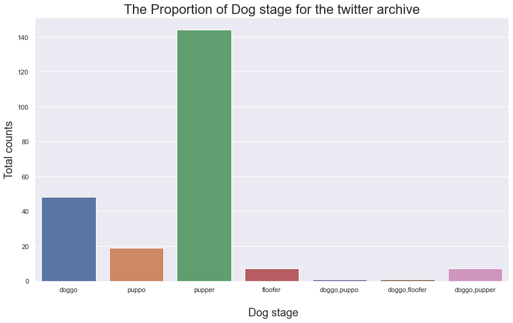

```python
#Initializing data value
data=df_twitter_archive_master

# Dog stage visualization
plt.figure(figsize=(14,8))
sns.set_theme(color_codes=True)
sns.countplot(x='dog_stage', data=data)
plt.title("The Proportion of Dog stage for the twitter archive",fontsize=22);
plt.ylabel('Total counts',fontsize=18);
plt.xlabel("\n Dog stage", fontsize=18);
```

### Insights #2: Which tweet source is the most populous amongst users?

```python
df_twitter_archive_master.source.value_counts()
```

```
Twitter for iPhone    1437
Twitter Web Client      19
TweetDeck                7
Name: source, dtype: int64
```

### Visualization

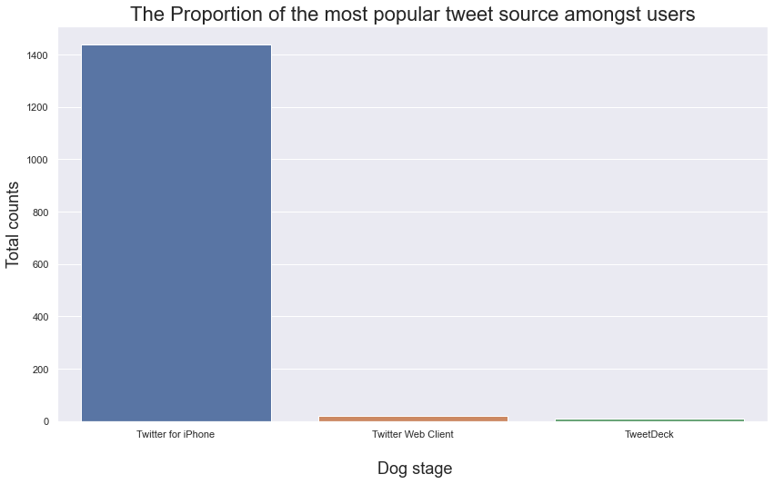

```python
plt.figure(figsize=(14,8))
sns.countplot(x='source', data=df_twitter_archive_master);
plt.title("The Proportion of the most popular tweet source amongst users",fontsize=22);
plt.ylabel('Total counts',fontsize=18);
plt.xlabel("\n Dog stage", fontsize=18);
```

> Twitter for iphone appears to be the most popular source amongst the users, followed by Twitter Web client and TweetDeck as the least used among the different sources.

### Insights #3: Which dog breed is the most predicted for the period of investigation?

```python
df_twitter_archive_master.p1.value_counts()
```

```
golden_retriever      137
Labrador_retriever     94
Pembroke               88
Chihuahua              78
pug                    54
                     ...
Scotch_terrier          1
EntleBucher             1
Japanese_spaniel        1
standard_schnauzer      1
clumber                 1
Name: p1, Length: 111, dtype: int64
```

### VISUALIZATION

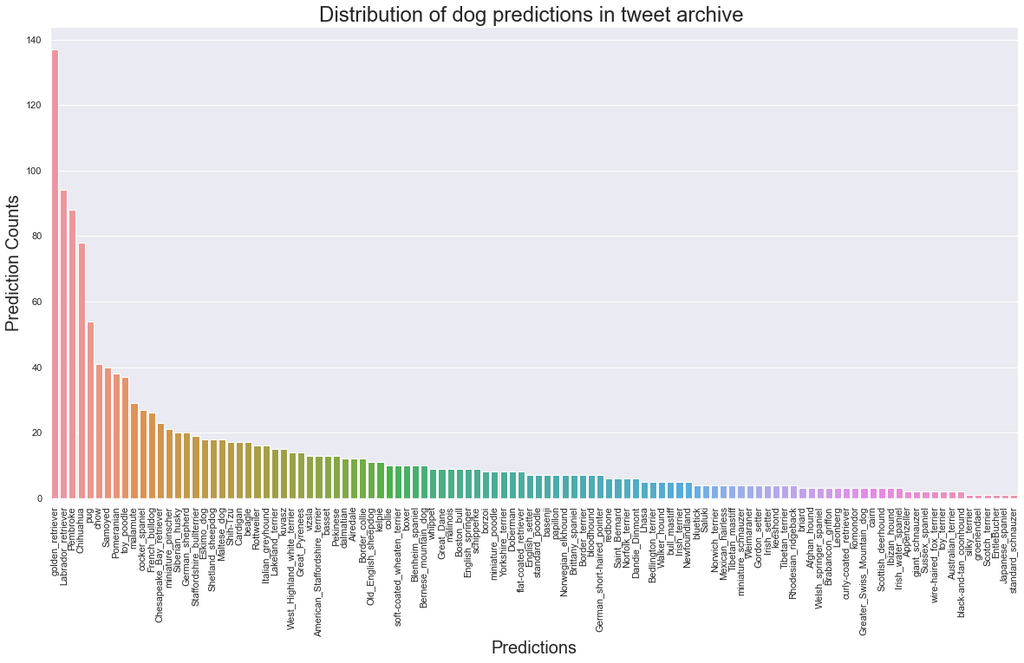

```python
plt.figure(figsize=(20,10))
sns.countplot(x='p1', order= data.p1.value_counts().index[0:-1], data=data);
plt.title("Distribution of dog predictions in tweet archive ",fontsize=24)
plt.xlabel("Predictions",fontsize=20)
plt.xticks(rotation=90)
plt.ylabel("Prediction Counts",fontsize=20);
```

> Golden_retriever appears to be the most predicted with total predication of 137, followed by labrador_retriever with count 94. The leasts predicted are Scotch_terrier, EntleBucher, Japanese_spaniel, standard_schnauzer, clumber with predictions of 1.

### Insights #4: Is there a relationship between retweet_count and favorite_count?

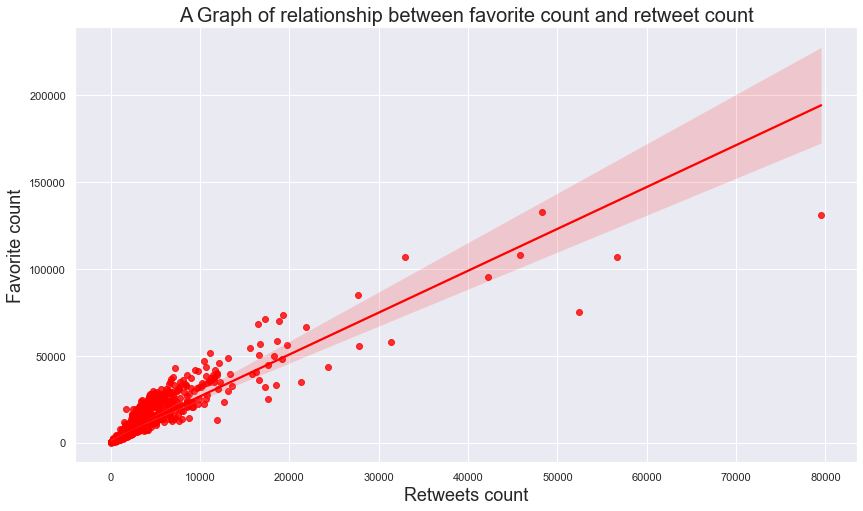

```python
sns.set_theme(color_codes=True)
plt.figure(figsize=(14,8))
sns.regplot(x = "retweets_count", y = "favorite_count",
            data = data, color='red');
plt.title("A Graph of relationship between favorite count and retweet count",fontsize=20);
plt.xlabel("Retweets count",fontsize=18);
plt.ylabel("Favorite count", fontsize=18);
```

> It can be observed from the above graph there exist a positive relationship between favorite count and retweets count. This implies dog with higher retweets are the most favorites. Let's further drive our points with testing the strenght of relationships.

```python
np.corrcoef(data.retweets_count, data.favorite_count)
```

```
array([[1.        , 0.91103578],
       [0.91103578, 1.        ]])
```

> The above correlation coefficient output shows the strenght of relationship at 91%, which marks a very strong positive relationship between retweet counts and favorite counts.

### Insight #5: Which dog breed and dog stage have the most retweets and favorite count?

```python
df_twitter_archive_master.sort_values(by='retweets_count',ascending=False)[['dog_stage','p1','retweets_count','favorite_count']]
```

|  | dog_stage | p1 | retweets_count | favorite_count |
| --- | --- | --- | --- | --- |
| 614 | doggo | Labrador_retriever | 79515 | 131075 |
| 324 | NaN | Chihuahua | 56625 | 107015 |
| 639 | doggo | Eskimo_dog | 52360 | 75163 |
| 247 | puppo | Lakeland_terrier | 48265 | 132810 |
| 51 | NaN | English_springer | 45849 | 107956 |
| ... | ... | ... | ... | ... |
| 1303 | NaN | Dandie_Dinmont | 45 | 267 |
| 1441 | NaN | black-and-tan_coonhound | 44 | 113 |
| 1458 | NaN | miniature_pinscher | 41 | 111 |
| 1435 | NaN | curly-coated_retriever | 23 | 107 |
| 1448 | NaN | English_setter | 16 | 81 |

1463 rows × 4 columns